# Chapter 5

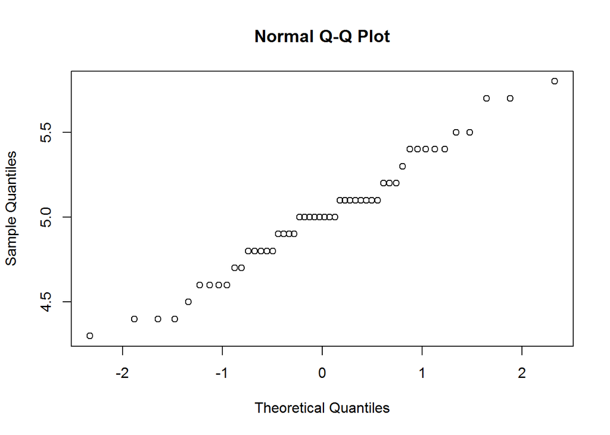

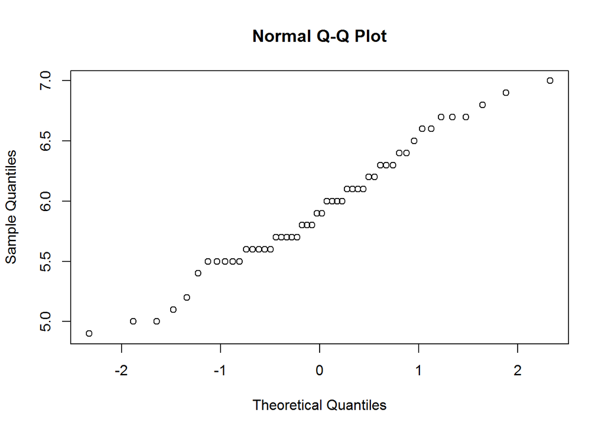

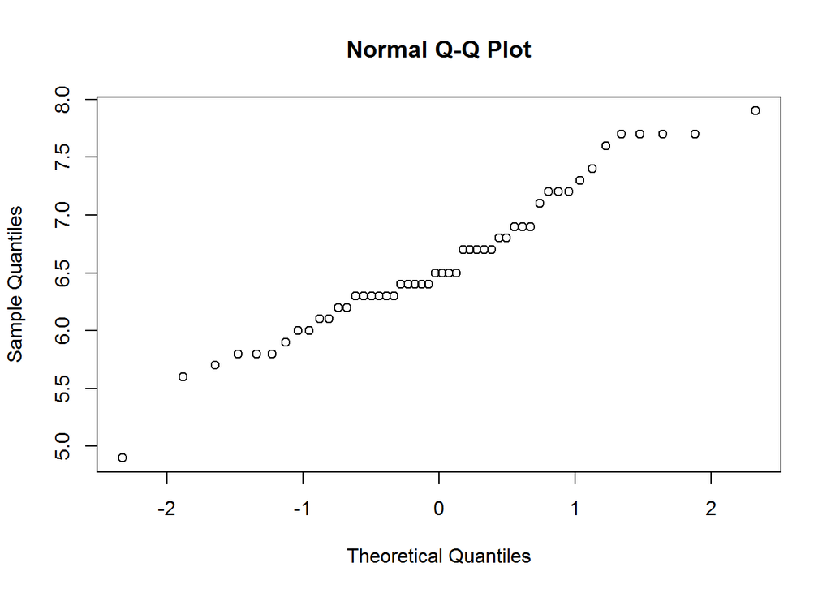

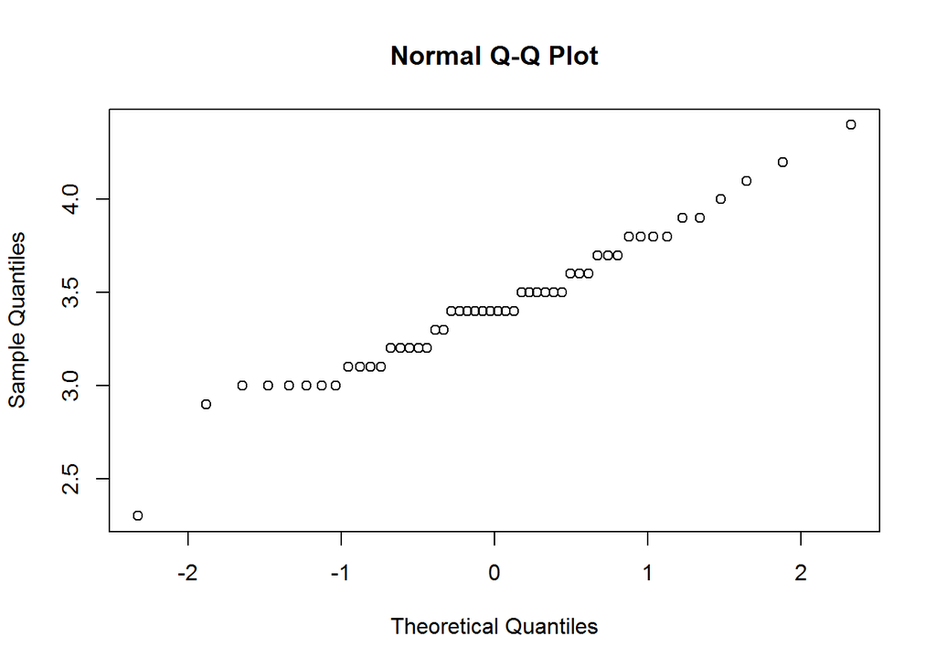

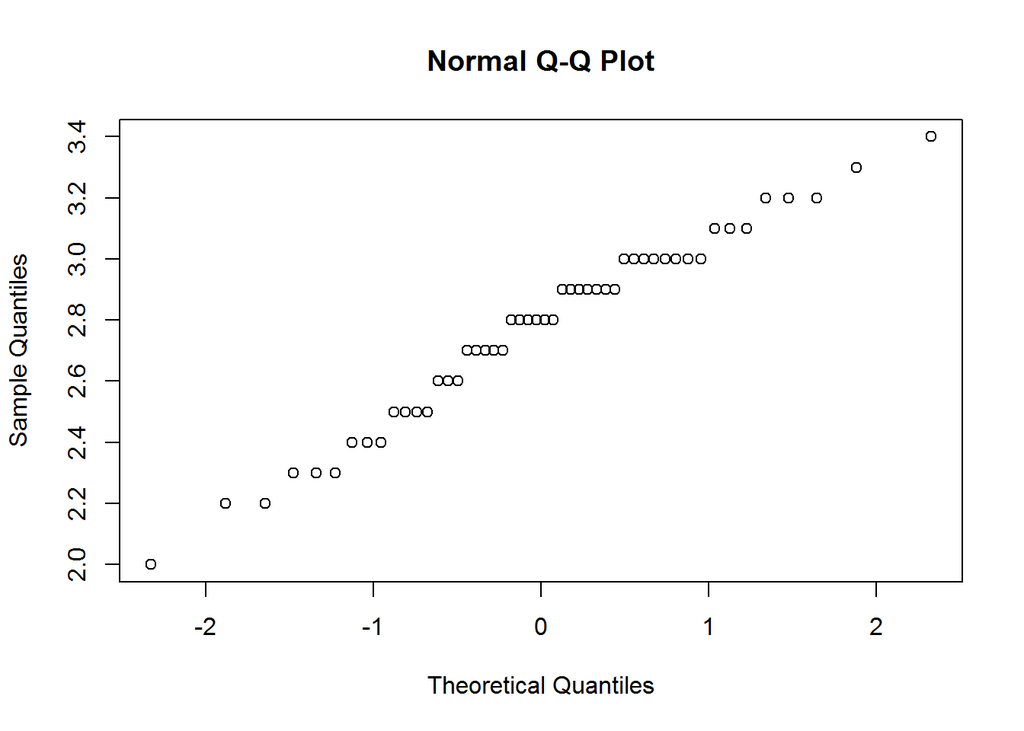

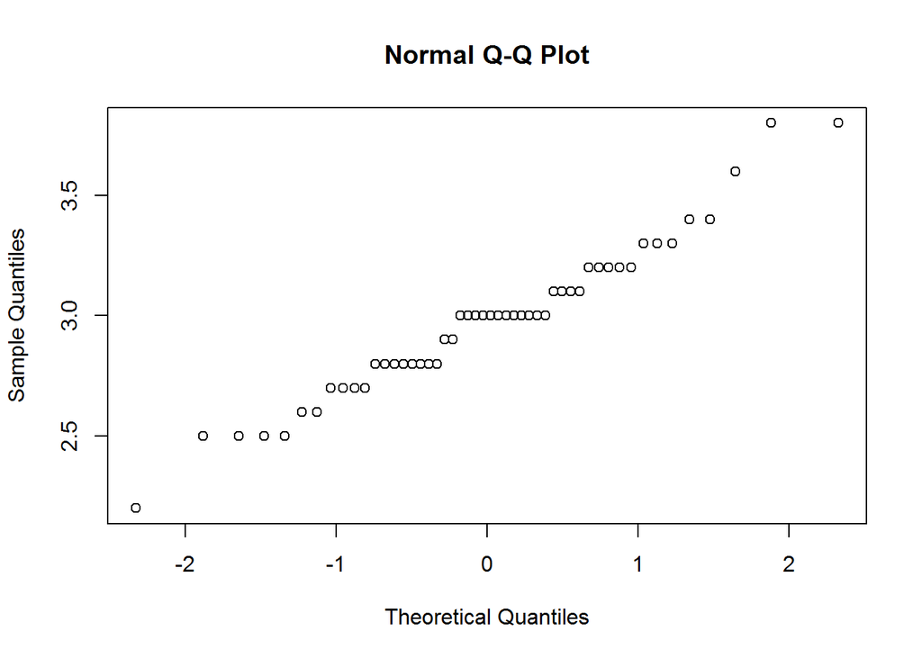

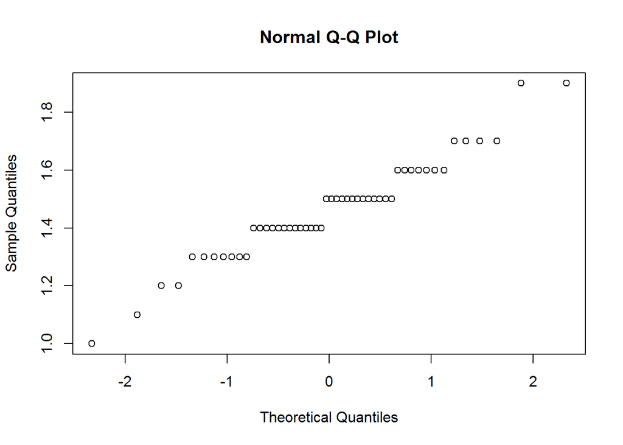

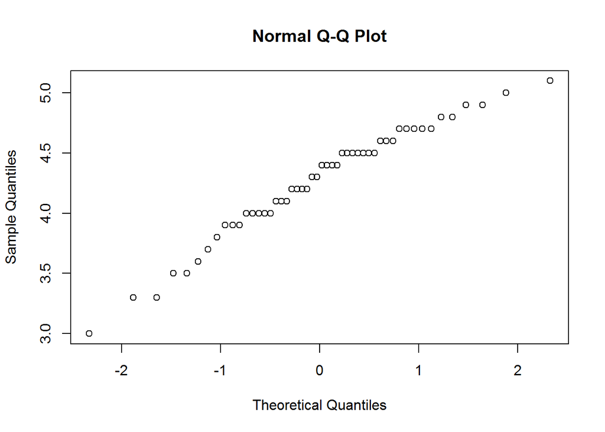

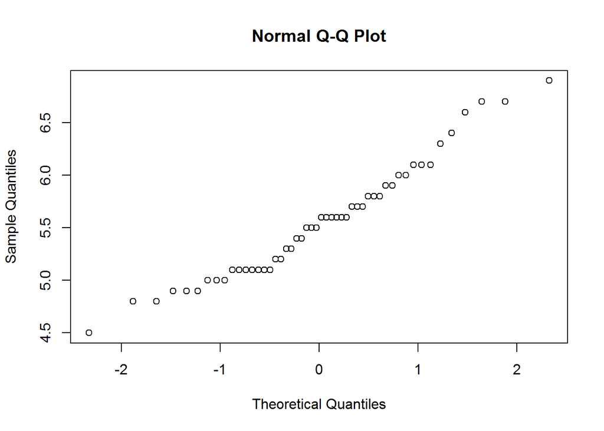

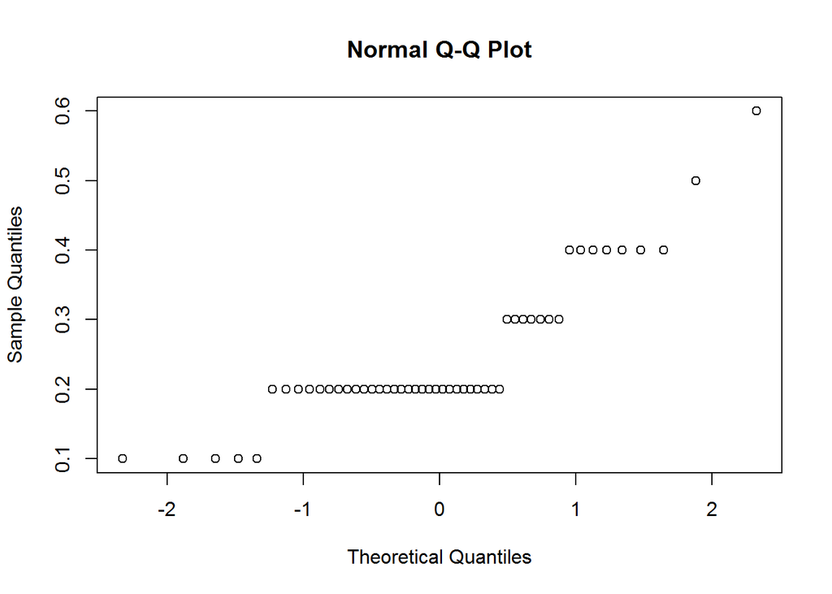

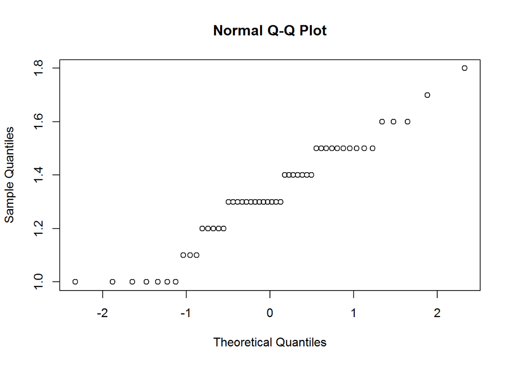

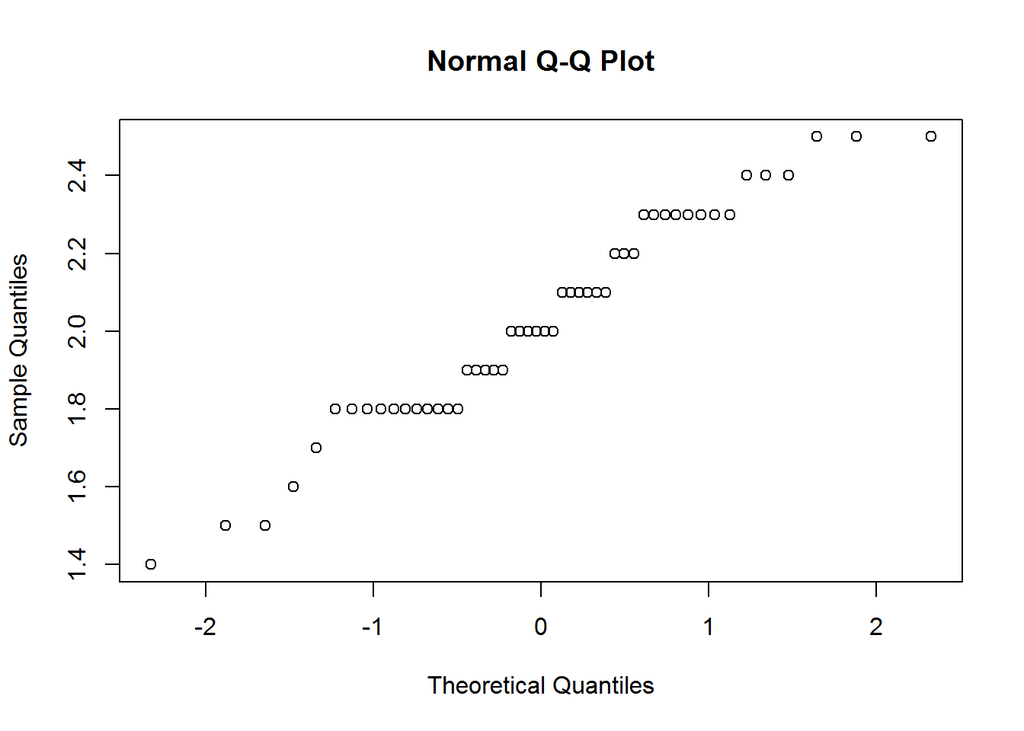

```r
for(j in 1:4){
  for(spec in levels(Species)){
    vect=iris[,j]
    qqnorm(vect[Species==spec])
  }
}
```

test accuracy for iris data

```r
train=sample(nrow(iris),round(.7*nrow(iris),0))
model=naiveBayes(Species~.,data=iris[train,])


predSpecies=predict(model,newdata=iris[-train,])
confmatrix(Species[-train],predSpecies)
```

```
## $matrix
##             predy
## y            setosa versicolor virginica
##   setosa         19          0         0
##   versicolor      0         15         0
##   virginica       0          1        10
##
## $accuracy
## [1] 0.9777778
##
## $error
## [1] 0.02222222
```

Discretizing iris

```r
x=cut(1:100,breaks=4)
is.factor(x)
```

```
## [1] TRUE
```

```r
disciris=iris

for(j in 1:4){
  disciris[,j]=as.factor(cut(iris[,j],4))

}


model=naiveBayes(Species~.,data=disciris[train,])


predSpecies=predict(model,newdata=disciris[-train,])
confmatrix(Species[-train],predSpecies)
```

```
## $matrix
##             predy
## y            setosa versicolor virginica
##   setosa         19          0         0
##   versicolor      0         15         0
##   virginica       0          2         9
##
## $accuracy
## [1] 0.9555556
##
## $error
## [1] 0.04444444
```

Modifying the cut function

```r
mycut=function(vector,numbreaks){
  probs=seq(from=0,to=1,by=1/numbreaks)
  breaks=quantile(vector,probs=probs)
  return(cut(vector,breaks=breaks))
}
```

Flight data

```r
flight<- read.csv(url("http://faculty.tarleton.edu/crawford/documents/Math5364/flight.csv"))
library(e1071)
cattime=cut(flight$schedtime,breaks=seq(from=600,to=2200,by=100),right=FALSE)
flight=cbind(flight,cattime)


set.seed(5364)
train=sample(nrow(flight),round(.7*nrow(flight),0))
model=naiveBayes(delay~carrier+dest+origin+weather+dayweek+cattime,data=flight[train,])
preddelay=predict(model,newdata=flight[-train,])
confmatrix(flight$delay[-train],preddelay)
```

```
## $matrix
##          predy
## y         delayed ontime
##   delayed       6    123
##   ontime        0    531
##
## $accuracy
## [1] 0.8136364
##
## $error
## [1] 0.1863636
```

```r
cmatrix=confmatrix(flight$delay[-train],preddelay)$matrix
```

Performance metrics

```r
TP=cmatrix[1,1]
TN=cmatrix[2,2]
FP=cmatrix[2,1]
FN=cmatrix[1,2]

acc=(TP+TN)/(TP+TN+FP+FN)
acc
```

```
## [1] 0.8136364
```

```r
TPR=TP/(TP+FN)
TNR=TN/(TN+FP)
FPR=FP/(FP+TN)
FNR=FN/(TP+FN)
TPR
```

```
## [1] 0.04651163
```

```r
TNR
```

```
## [1] 1
```

```r
FPR
```

```
## [1] 0
```

```r
FNR
```

```
## [1] 0.9534884
```

```r
p=TP/(TP+FP)
r=TP/(TP+FN)
p
```

```
## [1] 1
```

```r
r
```

```
## [1] 0.04651163
```

```r
F1=2*r*p/(r+p)
F1
```

```
## [1] 0.08888889
```

Examples with F1

```r
F1=function(r,p){
  return(2*r*p/(r+p))
}

F1(0.8,0.7)
```

```
## [1] 0.7466667
```

```r
F1(0.2,0.85)
```

```
## [1] 0.3238095
```

```r
F1(0.75,0.1)
```

```
## [1] 0.1764706
```

## Probability threshold

### naiveBayes

HouseVotes84 data

```r
library(mlbench)
data(HouseVotes84)

housetrain=sample(nrow(HouseVotes84),round(0.7*nrow(HouseVotes84),0))
housemodel = naiveBayes(Class ~ ., data = HouseVotes84[housetrain,])
predClass=predict(housemodel,newdata=HouseVotes84[-housetrain,])
confmatrix(HouseVotes84$Class[-housetrain],predClass)
```

```
## $matrix
##             predy
## y            democrat republican
##   democrat         78         12
##   republican        3         38
##
## $accuracy
## [1] 0.8854962
##
## $error
## [1] 0.1145038
```

phat for naiveBayes

```r
table(HouseVotes84$Class)
```

```
##
##   democrat republican
##        267        168
```

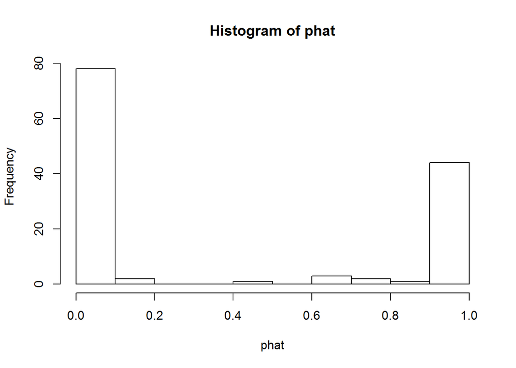

```r
phat=predict(housemodel,newdata=HouseVotes84[-housetrain,],type="raw")[,2]
hist(phat)
```

```r
table(predClass,(phat>=0.5))
```

```
##
## predClass    FALSE TRUE
##   democrat      81    0
##   republican     0   50
```

phat for decision tree

```r
library(rpart)
library(rattle)
```

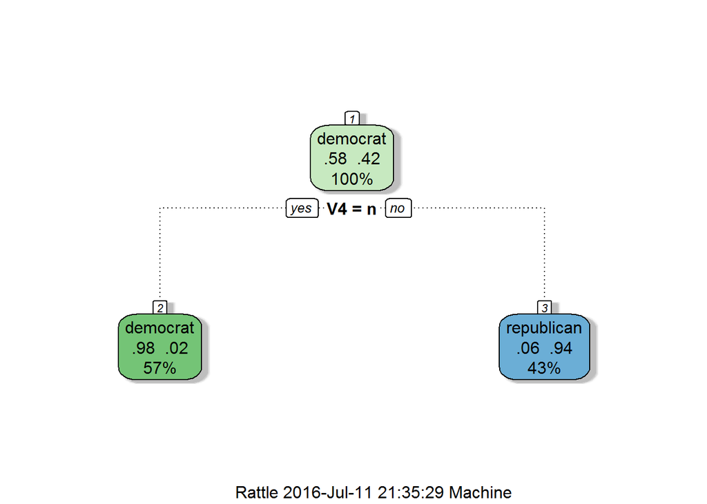

```r
mytree=rpart(Class~.,data=HouseVotes84[housetrain,])
fancyRpartPlot(mytree)
```

```r
treepredClass=predict(mytree,newdata=HouseVotes84[-housetrain,],type="class")
confmatrix(HouseVotes84$Class[-housetrain],treepredClass)
```

```
## $matrix
##             predy
## y            democrat republican
##   democrat         83          7
##   republican        1         40
##
## $accuracy
## [1] 0.9389313
##
## $error
## [1] 0.0610687
```

```r
treephat=predict(mytree,newdata=HouseVotes84[-housetrain,])[,2]
table(treepredClass,(treephat>=0.5))
```

```
##
## treepredClass FALSE TRUE
##    democrat      84    0
##    republican     0   47
```

phat for kknn

```r
modHouse=HouseVotes84
for(j in 2:17){
  levels(modHouse[,j])=c("n","y","abstain")
}
modHouse[is.na(modHouse)]="abstain"
modHouse
```

[output not shown]

[output cut: 1293 more lines]

```r
kknnfit=train.kknn(Class~.,data=modHouse)
kknnfit
```

```
##
## Call:
## train.kknn(formula = Class ~ ., data = modHouse)
##
## Type of response variable: nominal
## Minimal misclassification: 0.06436782
## Best kernel: optimal
## Best k: 7
```

```r
kknnmodel=kknn(Class~.,train=modHouse[housetrain,],
               test=modHouse[-housetrain,],kernel="optimal",k=7)

kknnpredClass=kknnmodel$fitted.values
confmatrix(HouseVotes84$Class[-housetrain],kknnpredClass)
```

```
## $matrix
##             predy
## y            democrat republican
##   democrat         79         11
##   republican        3         38
##
## $accuracy
## [1] 0.8931298
##
## $error
## [1] 0.1068702
```

```r
kknnphat=(kknnmodel$prob)[,2]
table(kknnpredClass,(kknnphat>=0.5))
```

```
##
## kknnpredClass FALSE TRUE
##    democrat      82    0
##    republican     0   49
```

phat for flight data

```r
phat=predict(model,newdata=flight[-train,],type="raw")[,1]
table(preddelay,(phat>=0.5))
```

```
##
## preddelay FALSE TRUE
##   delayed     0    6
##   ontime    654    0
```

Tuning p0 with training data to optimize F1 for flight data

```r
trainphat=predict(model,newdata=flight[train,],type="raw")[,1]


trainprec=1:100
trainrecall=1:100
trainF1=1:100
range(trainphat)
```

```
## [1] 5.868304e-05 8.774163e-01
```

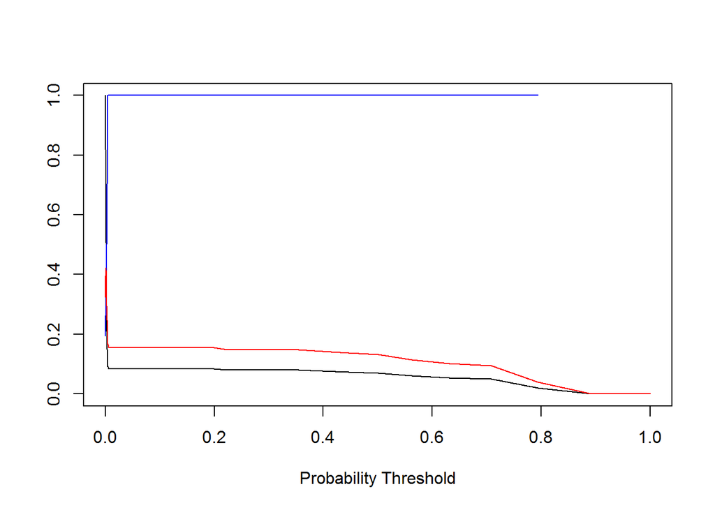

```r
p0vect=10^(-5+(1:100)/100*5)

for(i in 1:100){
  p0=p0vect[i]
  trainpreddelay=(trainphat>=p0)*1

  TP=sum((trainpreddelay==1)&(flight$delay[train]=="delayed"))
  FP=sum((trainpreddelay==1)&(flight$delay[train]!="delayed"))
  FN=sum((trainpreddelay!=1)&(flight$delay[train]=="delayed"))

  trainprec[i]=TP/(TP+FP)
  trainrecall[i]=TP/(TP+FN)
  trainF1[i]=2*TP/(2*TP+FP+FN)

}

plot(p0vect,trainrecall,type='l',xlab="Probability Threshold",ylab="")
lines(p0vect,trainprec,col="blue")
lines(p0vect,trainF1,col='red')
```

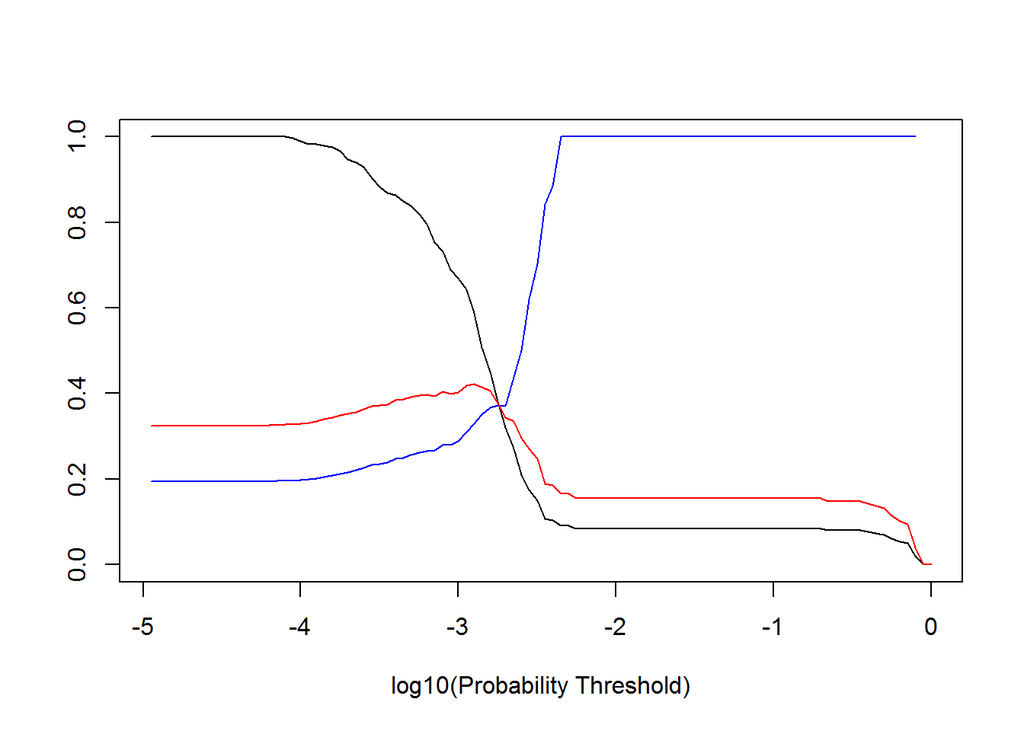

```r
plot(log(p0vect,base=10),trainrecall,type='l',xlab="log10(Probability Threshold)",ylab="")
lines(log(p0vect,base=10),trainprec,col="blue")
lines(log(p0vect,base=10),trainF1,col='red')
```

```r
which.max(trainF1)
```

```
## [1] 42
```

```r
trainF1[which.max(trainF1)]
```

```
## [1] 0.4220624
```

```r
trainprec[which.max(trainF1)]
```

```
## [1] 0.328972
```

```r
trainrecall[which.max(trainF1)]
```

```
## [1] 0.5886288
```

Validating on Test Data

```r
p0=p0vect[which.max(trainF1)]

testphat=predict(model,newdata=flight[-train,],type="raw")[,1]
newpreddelay=testphat
newpreddelay[testphat>=p0]="delayed"
newpreddelay[testphat<p0]="ontime"


confmatrix(flight$delay[-train],newpreddelay)
```

```
## $matrix
##          predy
## y         delayed ontime
##   delayed      69     60
##   ontime      163    368
##
## $accuracy
## [1] 0.6621212
##
## $error
## [1] 0.3378788
```

```r
cmatrix=confmatrix(flight$delay[-train],newpreddelay)$matrix
```

Performance metrics of flight data predictions

```r
TP=cmatrix[1,1]
TN=cmatrix[2,2]
FP=cmatrix[2,1]
FN=cmatrix[1,2]

acc=(TP+TN)/(TP+TN+FP+FN)
acc
```

```
## [1] 0.6621212
```

```r
TPR=TP/(TP+FN)
TNR=TN/(TN+FP)
FPR=FP/(FP+TN)
FNR=FN/(TP+FN)
TPR
```

```
## [1] 0.5348837
```

```r
TNR
```

```
## [1] 0.693032
```

```r
FPR
```

```
## [1] 0.306968
```

```r
FNR
```

```
## [1] 0.4651163
```

```r
p=TP/(TP+FP)
r=TP/(TP+FN)
p
```

```
## [1] 0.2974138
```

```r
r
```

```
## [1] 0.5348837
```

```r
F1=2*r*p/(r+p)
F1
```

```
## [1] 0.3822715
```

# HouseVotes84 naiveBayes

### ROC for HouseVotes84 naiveBayes model

```r
housetrain=sample(nrow(HouseVotes84),round(0.7*nrow(HouseVotes84),0))
housemodel = naiveBayes(Class ~ ., data = HouseVotes84[housetrain,])

#phat for naiveBayes

phat=predict(housemodel,newdata=HouseVotes84[-housetrain,],type="raw")[,2]

library(pROC)
houseroc=roc(response=HouseVotes84$Class[-housetrain],predictor=phat)
houseroc
```

```
##
## Call:
## roc.default(response = HouseVotes84$Class[-housetrain], predictor = phat)
##
## Data: phat in 79 controls (HouseVotes84$Class[-housetrain] democrat) < 52 cases (HouseVotes84$Class[-housetrain] republican).
## Area under the curve: 0.9557
```

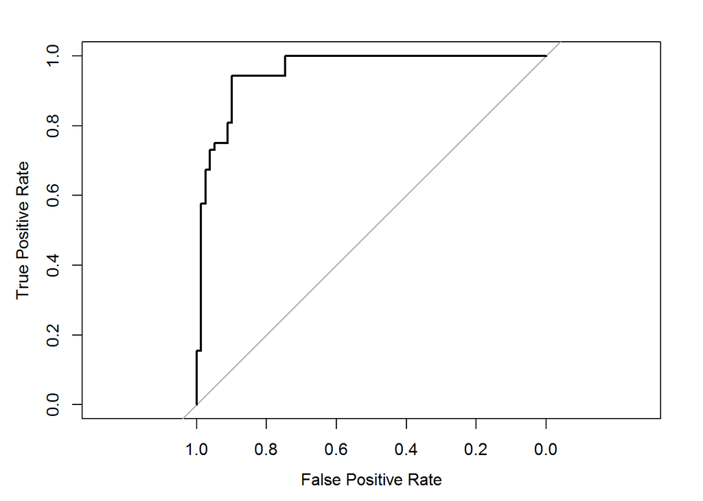

```
##
## Call:
## roc.default(response = HouseVotes84$Class[-housetrain], predictor = phat)
##
## Data: phat in 79 controls (HouseVotes84$Class[-housetrain] democrat) < 52 cases (HouseVotes84$Class[-housetrain] republican).
## Area under the curve: 0.9557
```

```r
plot(houseroc,ylab="True Positive Rate",xlab="False Positive Rate")
```

Flight data naiveBayes revisited

```r
cattime=cut(flight$schedtime,breaks=seq(from=600,to=2200,by=100),right=FALSE)
flight2=cbind(flight,cattime)


set.seed(5364)
train=sample(nrow(flight2),round(.7*nrow(flight2),0))
model=naiveBayes(delay~carrier+dest+origin+weather+dayweek+cattime,data=flight2[train,])
phat=predict(model,newdata=flight2[-train,],type="raw")[,1]

#ROC for Flight Data naiveBayes model
flightroc=roc(flight2$delay[-train]=="delayed",phat)
flightroc
```

```
##
## Call:
## roc.default(response = flight2$delay[-train] == "delayed", predictor = phat)
##
## Data: phat in 531 controls (flight2$delay[-train] == "delayed" FALSE) < 129 cases (flight2$delay[-train] == "delayed" TRUE).
## Area under the curve: 0.6749
```

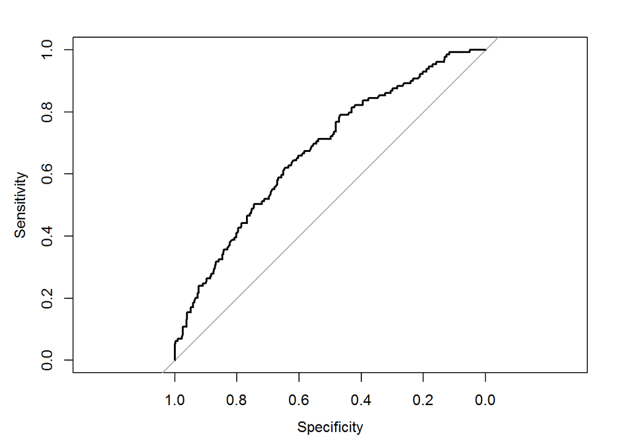

```
##
## Call:
## roc.default(response = flight2$delay[-train] == "delayed", predictor = phat)
##
## Data: phat in 531 controls (flight2$delay[-train] == "delayed" FALSE) < 129 cases (flight2$delay[-train] == "delayed" TRUE).
## Area under the curve: 0.6749
```

```r
plot(flightroc)
```

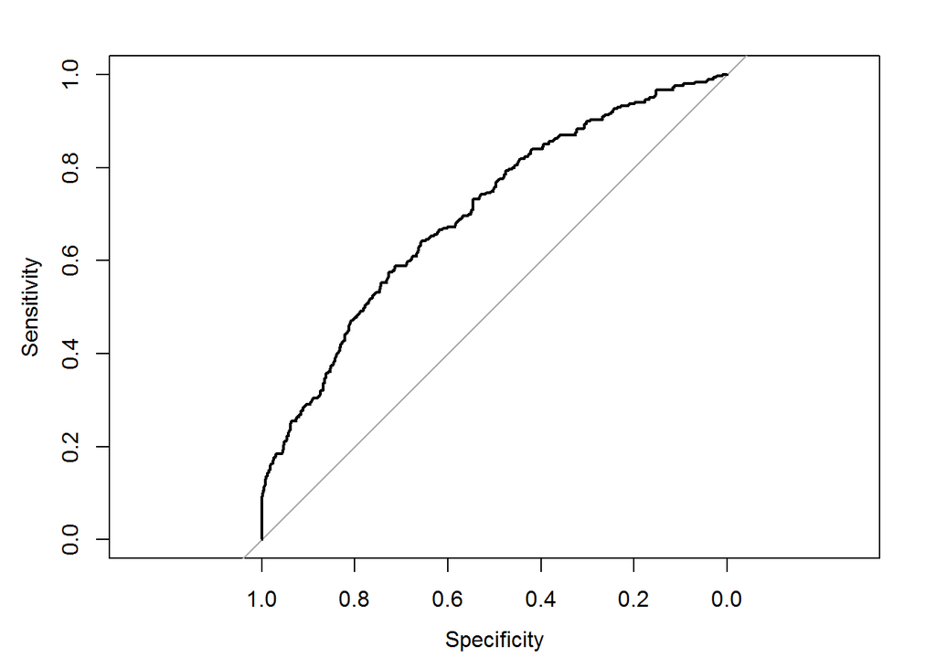

```
##
## Call:
## roc.default(response = flight2$delay[train] == "delayed", predictor = predict(model,     newdata = flight2[train, ], type = "raw")[, 1])
##
## Data: predict(model, newdata = flight2[train, ], type = "raw")[, 1] in 1242 controls (flight2$delay[train] == "delayed" FALSE) < 299 cases (flight2$delay[train] == "delayed" TRUE).
## Area under the curve: 0.7013
```

```r
#ROC for training data
flighttrainroc=roc(flight2$delay[train]=="delayed",
                   predict(model,newdata=flight2[train,],type="raw")[,1])
plot(flighttrainroc)
```

ROC for flight decision tree

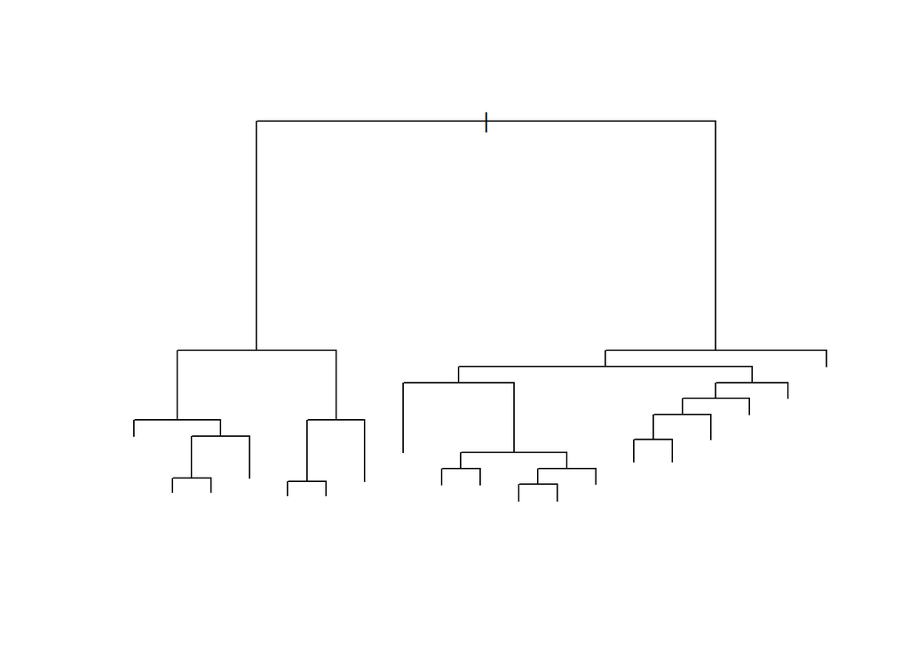

```r
flighttree=rpart(delay~.,data=flight[train,])
plot(flighttree)
```

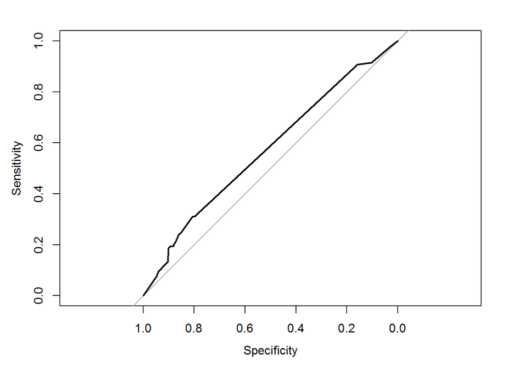

```
##
## Call:
## roc.default(response = flight$delay[-train] == "delayed", predictor = treephat)
##
## Data: treephat in 531 controls (flight$delay[-train] == "delayed" FALSE) < 129 cases (flight$delay[-train] == "delayed" TRUE).
## Area under the curve: 0.5714
```

```r
treephat=predict(flighttree,newdata=flight[-train,])[,1]
plot(roc(flight$delay[-train]=="delayed",treephat))
```

ROC for flight kknn

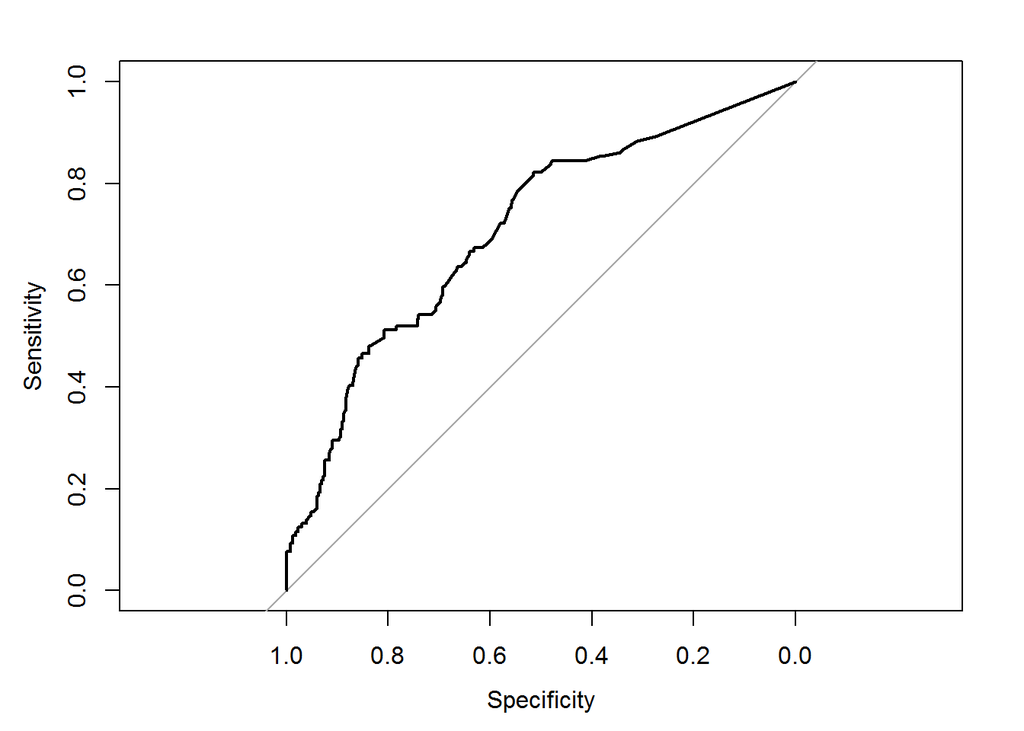

```
##
## Call:
## roc.default(response = flight$delay[-train] == "delayed", predictor = kknnphat)
##
## Data: kknnphat in 531 controls (flight$delay[-train] == "delayed" FALSE) < 129 cases (flight$delay[-train] == "delayed" TRUE).
## Area under the curve: 0.7082
```

```r
flightkknn.fit=train.kknn(delay~.,data=flight[train,])
kknnmodel=kknn(delay~.,train=flight[train,],test=flight[-train,],k=10,kernel="optimal")
kknnphat=kknnmodel$prob[,1]
plot(roc(flight$delay[-train]=="delayed",kknnphat))
```

Hosmer-Lemeshow Test

```r
hlgof=function(pihat,Y,ngr){
  sortframe=sort(pihat,index=TRUE)
  pihat=sortframe$x
  Y=Y[sortframe$ix]
  s=floor(length(pihat)/ngr)  #groupsize
  pipred=1:ngr
  piobs=1:ngr
  Chat=0

  for(i in 1:ngr){
    index=(((i-1)*s+1):(i*s))
    if(i==ngr){index=(((i-1)*s+1):(length(pihat)))}
    pipred[i]=mean(pihat[index])
    nk=length(index)
    ok=sum(Y[index])
    piobs[i]=ok/nk
    Chat=Chat+(ok-nk*pipred[i])^2/(nk*pipred[i]*(1-pipred[i]))}

  pvalue=1-pchisq(Chat,ngr-2)
  return(list(pipred=pipred,piobs=piobs,Chat=Chat,pvalue=pvalue))}
```

Hosmer-Lemeshow Goodness of Fit Plot for naiveBayes Model

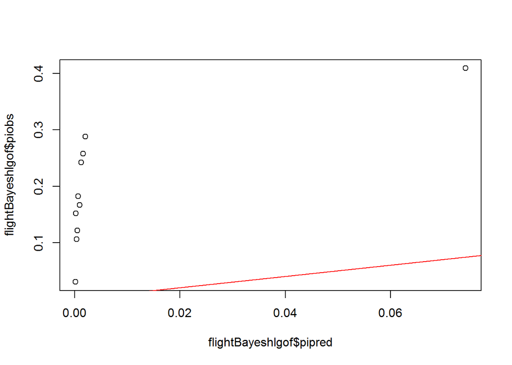

```r
flightBayeshlgof=hlgof(phat,flight$delay[-train]=="delayed",10)
plot(flightBayeshlgof$pipred,flightBayeshlgof$piobs)
lines(c(0,1),c(0,1),col='red')
```

Hosmer-Lemeshow Goodness of Fit Plot for kknn Model

```r
flightkknnhlgof=hlgof(kknnphat,flight$delay[-train]=="delayed",10)
flightkknnhlgof
```

```
## $pipred
##  [1] 0.00000000 0.00000000 0.00704579 0.04529758 0.09888246 0.15045147
##  [7] 0.20893684 0.28257911 0.37519871 0.59730590
##
## $piobs
##  [1] 0.09090909 0.07575758 0.09090909 0.04545455 0.18181818 0.22727273
##  [7] 0.22727273 0.15151515 0.43939394 0.42424242
##
## $Chat
## [1] Inf
##
## $pvalue
## [1] 0
```

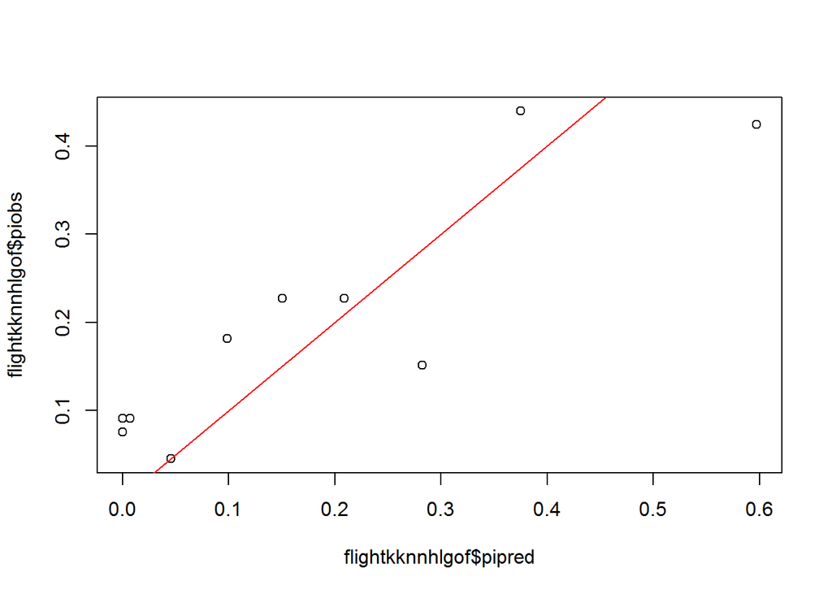

```r
plot(flightkknnhlgof$pipred,flightkknnhlgof$piobs)
lines(c(0,1),c(0,1),col='red')
```

Cost Sensitive Analysis for kknn Model

```r
p0 = 1/6
newpreddelay=kknnphat
newpreddelay[kknnphat>=p0]="delayed"
newpreddelay[kknnphat<p0]="ontime"

cmatrix=confmatrix(flight$delay[-train],newpreddelay)$matrix
cmatrix
```

```
##          predy
## y         delayed ontime
##   delayed      84     45
##   ontime      188    343
```

```r
TP=cmatrix[1,1]
TN=cmatrix[2,2]
FP=cmatrix[2,1]
FN=cmatrix[1,2]

cost=1*FP+5*FN
cost
```

```
## [1] 413
```

Cost for Typical Model (p0 = 0.5)

```r
p0 = 0.5
newpreddelay=kknnphat
newpreddelay[kknnphat>=p0]="delayed"
newpreddelay[kknnphat<p0]="ontime"

cmatrix=confmatrix(flight$delay[-train],newpreddelay)$matrix
cmatrix
```

```
##          predy
## y         delayed ontime
##   delayed      18    111
##   ontime       21    510
```

```r
TP=cmatrix[1,1]
TN=cmatrix[2,2]
FP=cmatrix[2,1]
FN=cmatrix[1,2]

cost=1*FP+5*FN
cost
```

```
## [1] 576
```

# SVM Example (Separable Case)

Generating Example Data

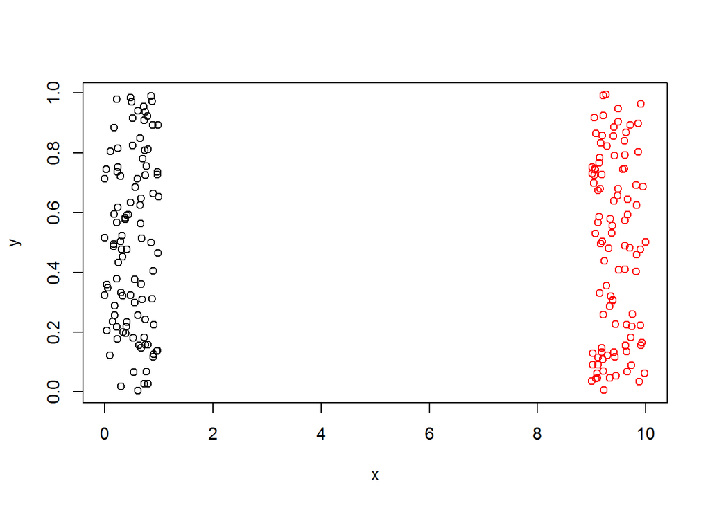

```r
x1=runif(100,0,1)
y1=runif(100,0,1)
x2=runif(100,9,10)
y2=runif(100,0,1)
class=c(rep("A",100),rep("B",100))
mydata=data.frame(x=c(x1,x2),y=c(y1,y2),class=class)
mydata$class=as.factor(mydata$class)
plot(y~x,data=mydata,col=class)
```

Split Data

```r
train=sample(nrow(mydata),round(nrow(mydata)*.7,0))

#Fit SVM Model to Training Data
model=svm(class~.,data=mydata[train,],kernel="linear",cost=1000)

#Make predictions for test data
predclass=predict(model,newdata=mydata[-train,])
confmatrix(predclass,mydata$class[-train])
```

```
## $matrix
##    predy
## y    A  B
##   A 28  0
##   B  0 32
##
## $accuracy
## [1] 1
##
## $error
## [1] 0
```

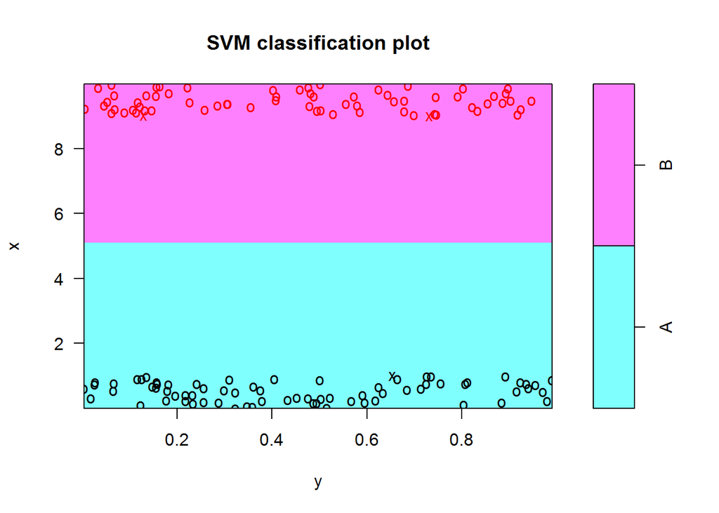

```r
#Plot model
plot(model,data=mydata[train,])
```

Model info

```r
model
```

```
##
## Call:
## svm(formula = class ~ ., data = mydata[train, ], kernel = "linear",
##     cost = 1000)
##
##
## Parameters:
##    SVM-Type:  C-classification
##  SVM-Kernel:  linear
##        cost:  1000
##       gamma:  0.5
##
## Number of Support Vectors:  3
```

```r
model$rho     #The negative intercept, i.e., rho = -b
```

```
## [1] -0.0359084
```

```r
model$SV      #Support vectors (All data is scaled, include SV's)
```

```
##              x        y.1
## 95  -0.8623072  0.6695141
## 196  0.9267736 -1.1189346
## 129  0.9244482  0.9322194
```

```r
model$index   #Positions in data set of SV's
```

```
## [1]  44  92 106
```

```r
model$coefs   #coef = lambda*y
```

```
##             [,1]
## [1,]  0.62646384
## [2,] -0.07961671
## [3,] -0.54684712
```

```r
#Calculating w and b
w=t(model$coefs)%*%(model$SV)
b=-model$rho
```

Checking SV’s

```r
(model$SV%*%t(w))+b              #The first component of this vector is always 1,
```

```
##          [,1]
## 95   1.000431
## 196 -1.000216
## 129 -1.000216
```

```r
mydata[train,][model$index,]     #which determines the assignment of +1/-1 labels
```

```
##             x         y class
## 95  0.9940856 0.6536204     A
## 196 9.0218311 0.1293623     B
## 129 9.0113967 0.7306287     B
```

```r
#to the different classes.
```

Soft Margin Example

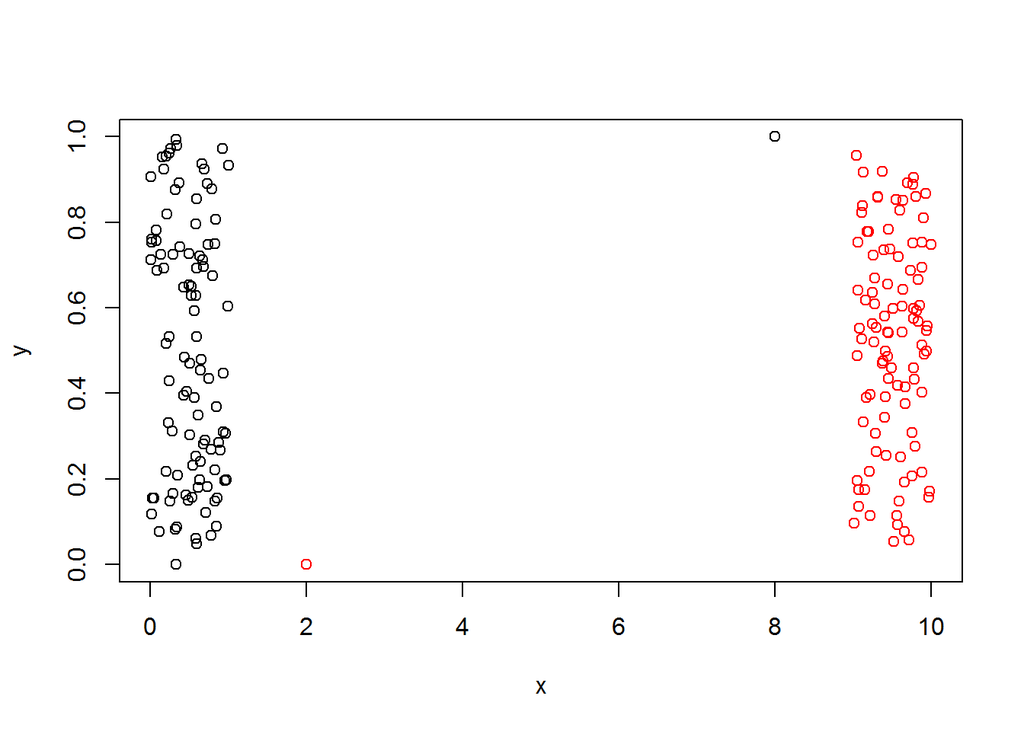

```r
set.seed(5364)
x1=runif(100,0,1)
y1=runif(100,0,1)
x2=runif(100,9,10)
y2=runif(100,0,1)
class=c(rep("A",100),rep("B",100))
x3=c(2,8)
y3=c(0,1)
class3=c("B","A")


mydata2=data.frame(x=c(x1,x2,x3),y=c(y1,y2,y3),class=c(class,class3))
mydata2$class=as.factor(mydata2$class)
plot(y~x,data=mydata2,col=class)
```

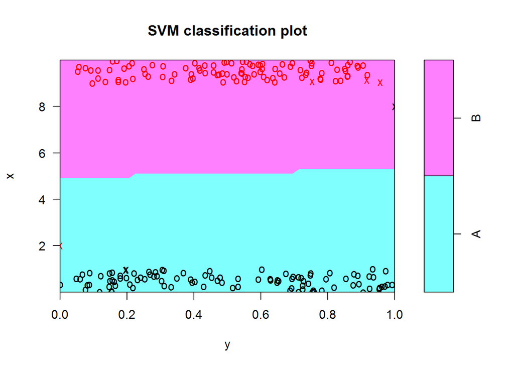

```r
softmodel=svm(class~.,data=mydata2,kernel="linear",cost=1)
plot(softmodel,data=mydata2)
```

Overlapping data

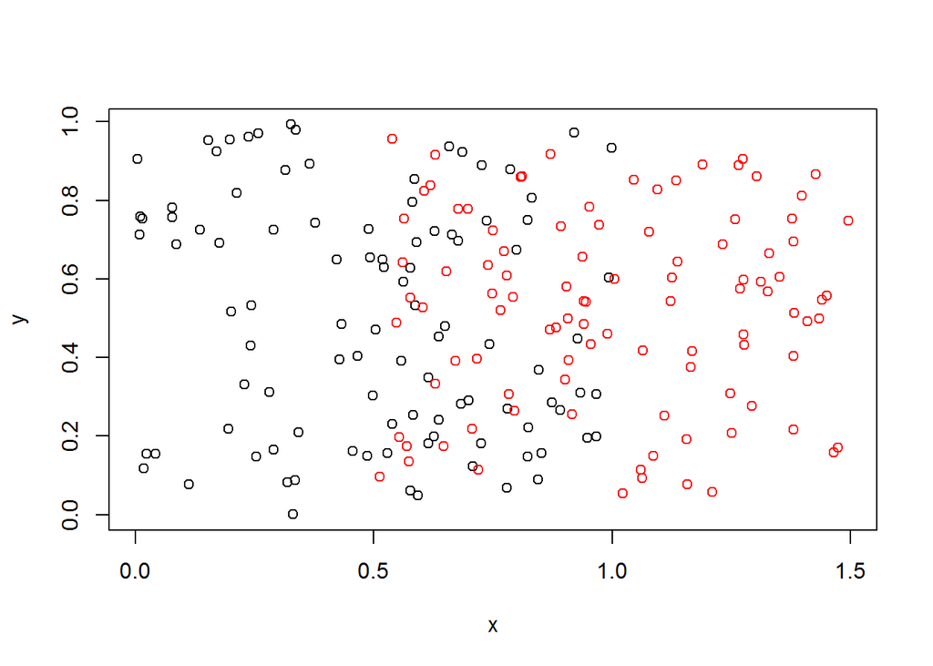

```r
mydata3=data.frame(x=c(x1,x2-8.5),y=c(y1,y2),class=c(class))
mydata3$class=as.factor(mydata3$class)
plot(y~x,data=mydata3,col=class)
```

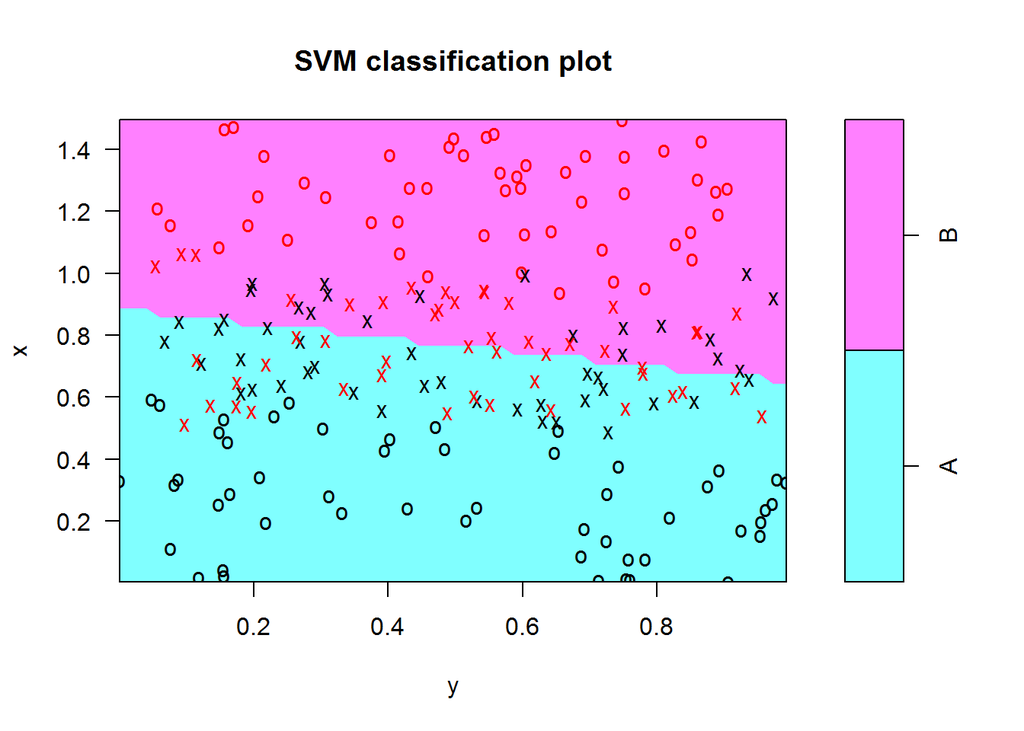

```r
overlapmodel=svm(class~.,data=mydata3,kernel="linear")
plot(overlapmodel,data=mydata3)
```

```r
confmatrix(mydata3$class,predict(overlapmodel,data=mydata3))
```

```
## $matrix
##    predy
## y    A  B
##   A 79 21
##   B 23 77
##
## $accuracy
## [1] 0.78
##
## $error
## [1] 0.22
```

Circular data

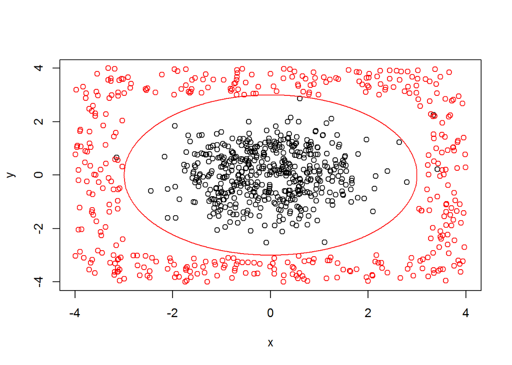

```r
circledata=data.frame(
  x=c(rnorm(500),
      runif(100,-4,-3),
      runif(100,3,4),
      runif(100,-3,3),
      runif(100,-3,3)),
  y=c(rnorm(500),
      runif(100,-4,4),
      runif(100,-4,4),
      runif(100,3,4),
      runif(100,-4,-3)),
  class=as.factor(c(rep("A",500),
                    rep("B",400))))

plot(y~x,data=circledata,col=class)
xindex=(-300:300)/100
lines(xindex,sqrt(9-xindex^2),col="red")
lines(xindex,-sqrt(9-xindex^2),col="red")
```

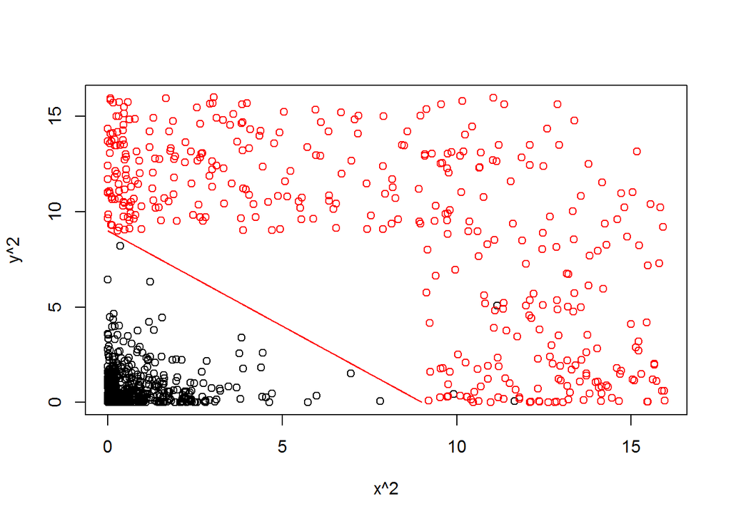

```r
plot(y^2~I(x^2),data=circledata,col=class,xlab="x^2",ylab="y^2")
xindex=(0:900)/100
lines(xindex,9-xindex,col="red")
```

SVM for circledata

```r
train=sample(nrow(circledata),round(nrow(circledata)*.7,0))

circlemodel=svm(class~.,data=circledata[train,],
                kernel="polynomial",gamma=1,coef0=1,degree=2)
circlemodel
```

```
##
## Call:
## svm(formula = class ~ ., data = circledata[train, ], kernel = "polynomial",
##     gamma = 1, coef0 = 1, degree = 2)
##
##
## Parameters:
##    SVM-Type:  C-classification
##  SVM-Kernel:  polynomial
##        cost:  1
##      degree:  2
##       gamma:  1
##      coef.0:  1
##
## Number of Support Vectors:  18
```

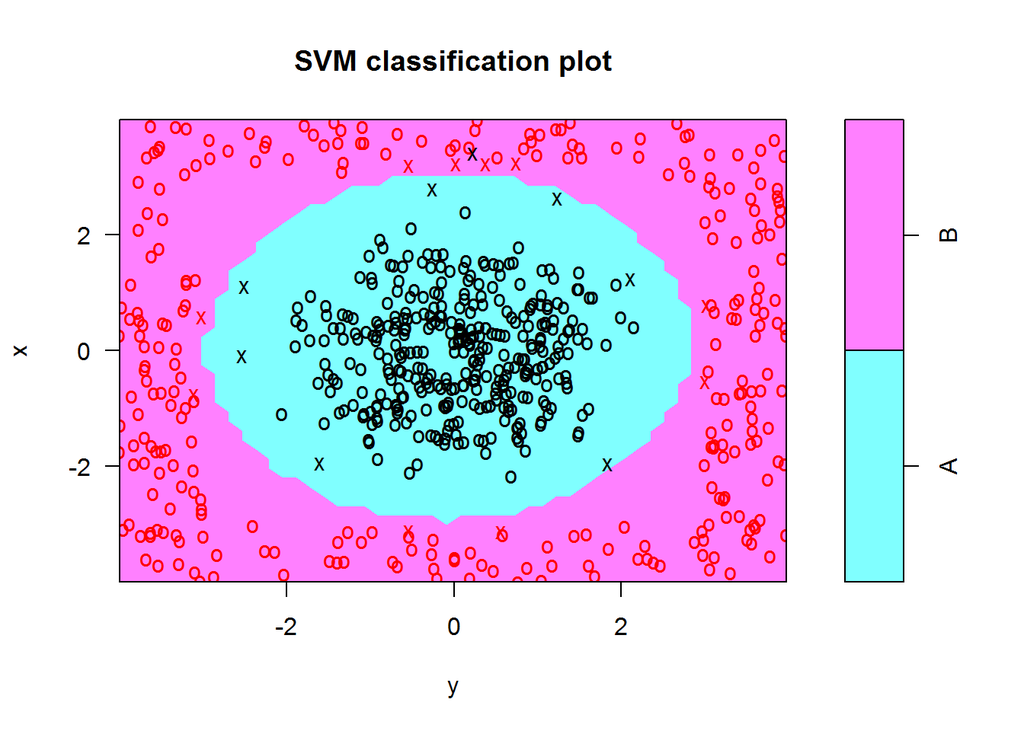

```r
plot(circlemodel,data=circledata[train,])
```

```r
predclass=predict(circlemodel,newdata=circledata[-train,])
confmatrix(circledata$class[-train],predclass)
```

```
## $matrix
##    predy
## y     A   B
##   A 148   3
##   B   0 119
##
## $accuracy
## [1] 0.9888889
##
## $error
## [1] 0.01111111
```

SVM for circledata without specifying kernel. Takes a while to run

```r
circlemodel=svm(class~.,data=circledata[train,])
circlemodel
```

```
##
## Call:
## svm(formula = class ~ ., data = circledata[train, ])
##
##
## Parameters:
##    SVM-Type:  C-classification
##  SVM-Kernel:  radial
##        cost:  1
##       gamma:  0.5
##
## Number of Support Vectors:  47
```

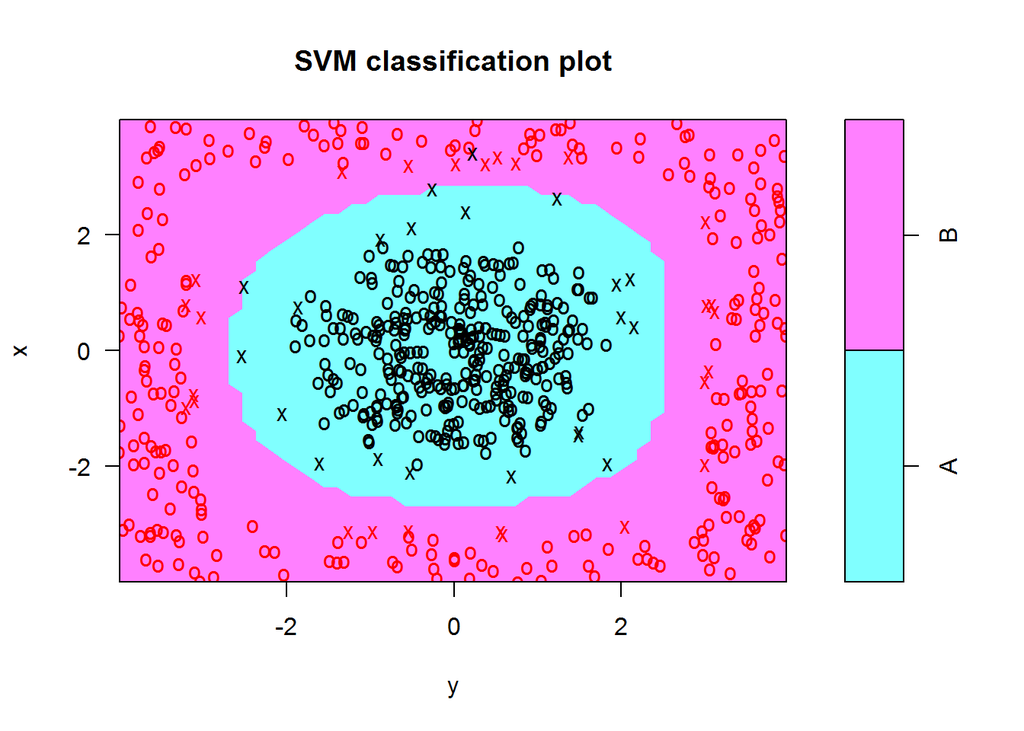

```r
plot(circlemodel,data=circledata[train,])
```

```r
predclass=predict(circlemodel,newdata=circledata[-train,])
confmatrix(circledata$class[-train],predclass)
```

```
## $matrix
##    predy
## y     A   B
##   A 148   3
##   B   0 119
##
## $accuracy
## [1] 0.9888889
##
## $error
## [1] 0.01111111
```

SVM for spam data

```r
library(kernlab)
data(spam)

set.seed(5364)
train=sample(nrow(spam),round(nrow(spam)*.7,0))

spammodel=svm(type~.,data=spam[train,])
confmatrix(spam$type[-train],
           predict(spammodel,newdata=spam[-train,]))
```

```
## $matrix
##          predy
## y         nonspam spam
##   nonspam     788   27
##   spam         58  507
##
## $accuracy
## [1] 0.9384058
##
## $error
## [1] 0.0615942
```

Tuning spam model

```r
tunespam=tune.svm(type~.,data=spam[train,],
                  gamma = 10^(-6:-3),
                  cost = 10^(1:2))
tunespam$best.parameters    #Gave gamma=0.001 and cost = 100
```

```
##   gamma cost
## 8 0.001  100
```

```r
spammodel2=svm(type~.,data=spam[train,],
               gamma=0.001,
               cost=100)
confmatrix(spam$type[-train],
           predict(spammodel2,newdata=spam[-train,]))
```

```
## $matrix
##          predy
## y         nonspam spam
##   nonspam     789   26
##   spam         58  507
##
## $accuracy
## [1] 0.9391304
##
## $error
## [1] 0.06086957
```

# NEURAL NETWORKS

Logistic Function

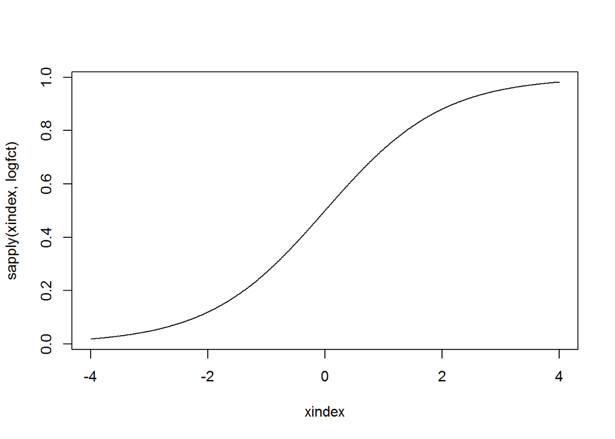

```r
logfct=function(x){
  1/(1 + exp(-x))
}

xindex=(-400:400)/100
plot(xindex,sapply(xindex,logfct),type="l")
```

```r
logfct(0)
```

```
## [1] 0.5
```

```r
logfct(Inf)
```

```
## [1] 1
```

```r
logfct(-Inf)
```

```
## [1] 0
```

sqrt function example

creating training data

```r
set.seed(5364)
x=runif(100,0,100)
y=sqrt(x)
traindata=data.frame('x'= x,'y'=y)
```

training a neural network

```r
library(nnet)
```

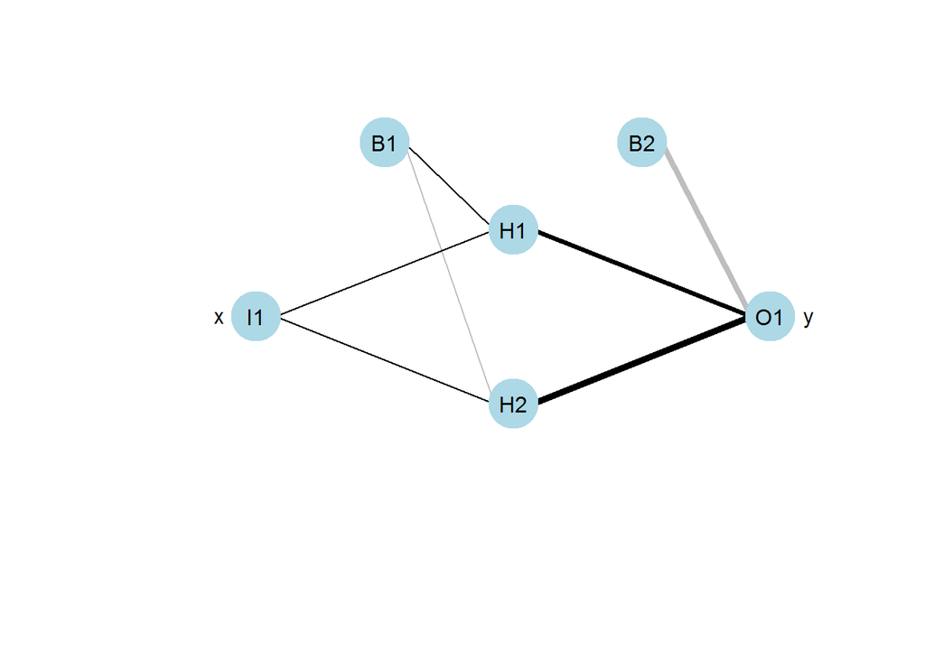

```r
source(url("http://faculty.tarleton.edu/crawford/documents/Math5364/plot.nnet.txt"))
model=nnet(y~.,data=traindata,size=2,linout=TRUE)  #linout=TRUE for quantitative output
plot(model)
```

```r
summary(model)
```

```
## Neural Network build options: linear output units.
##
## In the following table:
##    b  represents the bias associated with a node
##    h1 represents hidden layer node 1
##    i1 represents input node 1 (i.e., input variable 1)
##    o  represents the output node
##
## Weights for node h1:
##  b->h1 i1->h1
##   0.92   0.13
##
## Weights for node h2:
##  b->h2 i1->h2
##  -0.66   0.02
##
## Weights for node o:
##   b->o  h1->o  h2->o
## -10.17   8.94  13.29
```

```r
model$wts
```

```
## [1]   0.91714234   0.13036318  -0.65519488   0.02313398 -10.16636809
## [6]   8.94067627  13.28706236
```

creating test data

```r
testdata=data.frame(x=(1:10)^2,y=1:10)
#testdata  #uncomment to see the test data

#using neural network on test data
predy=predict(model,newdata=testdata)
data.frame(x=(1:10)^2,y=1:10,predy)
```

```
##      x  y    predy
## 1    1  1 1.063562
## 2    4  2 1.882123
## 3    9  3 2.973521
## 4   16  4 4.054498
## 5   25  5 5.027482
## 6   36  6 5.973727
## 7   49  7 6.971242
## 8   64  8 8.012977
## 9   81  9 9.029531
## 10 100 10 9.935388
```

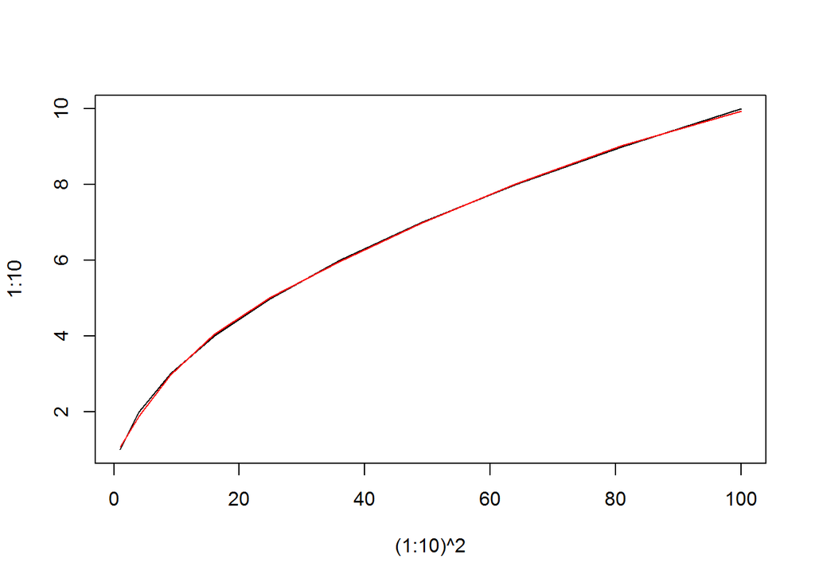

```r
plot((1:10)^2,1:10,type="l")
lines((1:10)^2,predy,col="red")
```

Calculating output for x=100

```r
h1=0.91714234+0.13036318*100
h2=-0.65519488+0.02313398*100
h1
```

```
## [1] 13.95346
```

```r
h2
```

```
## [1] 1.658203
```

```r
logfct(h1)
```

```
## [1] 0.9999991
```

```r
logfct(h2)
```

```
## [1] 0.8399966
```

```r
o1=-10.16636809+8.94067627*logfct(h1)+13.28706236*logfct(h2)
```

Neural network for sqrt function with 10 hidden neurons

```r
model2=nnet(y~.,data=traindata,size=10,linout=TRUE)
```

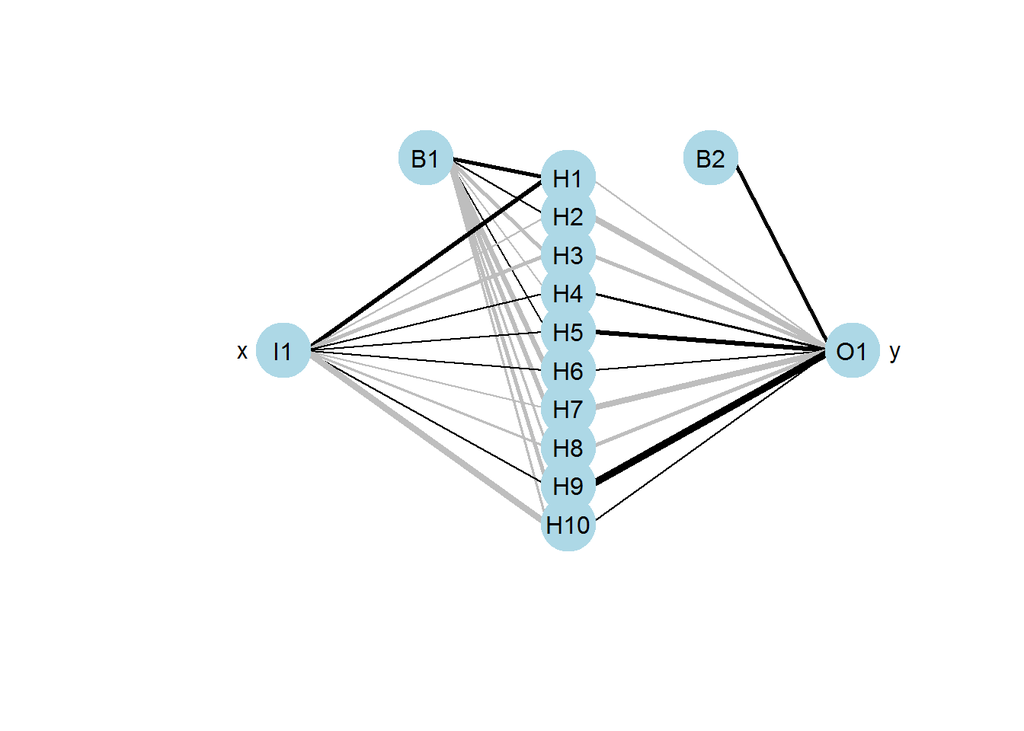

```r
plot(model2)
```

```r
predy2=predict(model2,newdata=testdata)

data.frame(x=(1:10)^2,y=1:10,predy,predy2)
```

```
##      x  y    predy    predy2
## 1    1  1 1.063562 0.9972017
## 2    4  2 1.882123 1.9963481
## 3    9  3 2.973521 3.0013962
## 4   16  4 4.054498 3.9995052
## 5   25  5 5.027482 5.0008592
## 6   36  6 5.973727 5.9982790
## 7   49  7 6.971242 7.0007337
## 8   64  8 8.012977 7.9989766
## 9   81  9 9.029531 8.9996267
## 10 100 10 9.935388 9.9965642
```

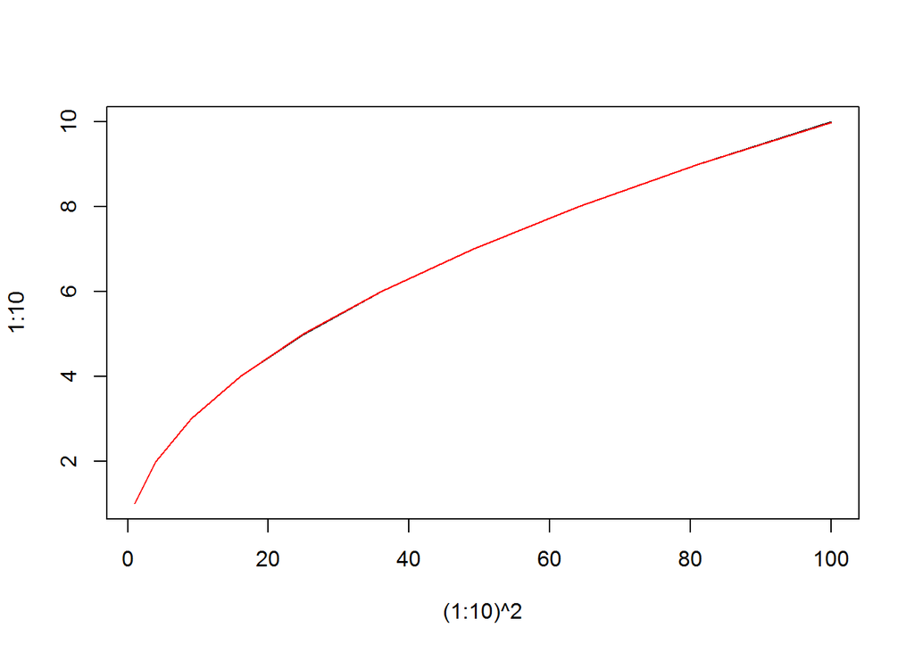

```r
plot((1:10)^2,1:10,type="l")
lines((1:10)^2,predy2,col="red")
```

### Neural Network for Iris Data

```r
set.seed(5364)
train=sample(nrow(iris),round(nrow(iris)*.7,0))

model=nnet(Species~Petal.Length+Petal.Width,data=iris[train,],size=2)
predSpecies=predict(model,newdata=iris[-train,],type="class")
confmatrix(iris$Species[-train],predSpecies)
```

```
## $matrix
##             predy
## y            setosa versicolor virginica
##   setosa         19          0         0
##   versicolor      0         11         1
##   virginica       0          1        13
##
## $accuracy
## [1] 0.9555556
##
## $error
## [1] 0.04444444
```

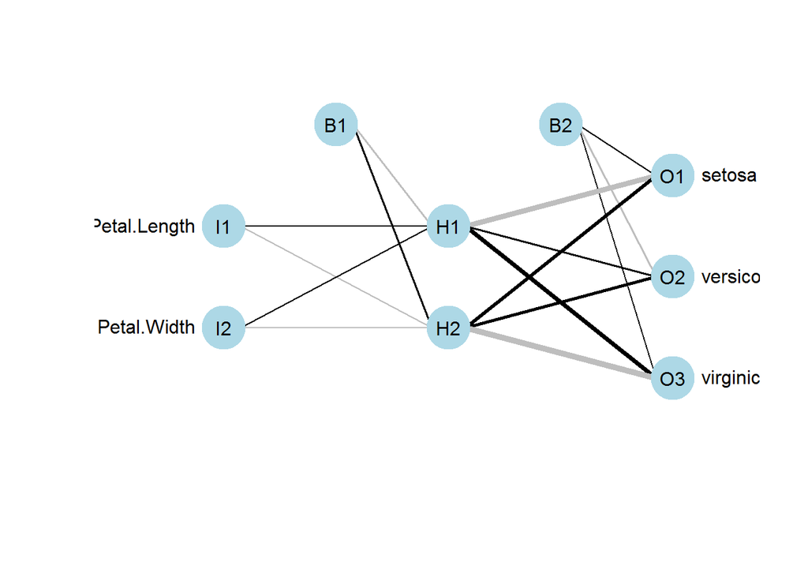

```r
plot(model)
```